{% raw %}

{% endraw %} {% raw %}

{% endraw %}

In this tutorial, we'll see how to use the data block API on a variety of tasks and how to debug data blocks. The data block API takes its name from the way it's designed: every bit needed to build the `DataLoaders` object (type of inputs, targets, how to label, split...) is encapsulated in a block, and you can mix and match those blocks

## Building a `DataBlock` from scratch

The rest of this tutorial will give many examples, but let's first build a `DataBlock` from scratch on the dogs versus cats problem we saw in the [vision tutorial](http://docs.fast.ai/tutorial.vision). First we import everything needed in vision.

{% raw %}

```python
from fastai.data.all import *
from fastai.vision.all import *
```

{% endraw %}

The first step is to download and decompress our data (if it's not already done) and get its location:

{% raw %}

```python
path = untar_data(URLs.PETS)
```

{% endraw %}

And as we saw, all the filenames are in the "images" folder. The `get_image_files` function helps get all the images in subfolders:

{% raw %}

```python
fnames = get_image_files(path/"images")
```

{% endraw %}

Let's begin with an empty `DataBlock`.

{% raw %}

```python
dblock = DataBlock()
```

{% endraw %}

By itself, a `DataBlock` is just a blue print on how to assemble your data. It does not do anything until you pass it a source. You can choose to then convert that source into a `Datasets` or a `DataLoaders` by using the `DataBlock.datasets` or `DataBlock.dataloaders` method. Since we haven't done anything to get our data ready for batches, the `dataloaders` method will fail here, but we can have a look at how it gets converted in `Datasets`. This is where we pass the source of our data, here all our filenames:

{% raw %}

```python
dsets = dblock.datasets(fnames)
dsets.train[0]
```

```
(Path('/home/jhoward/.fastai/data/oxford-iiit-pet/images/saint_bernard_141.jpg'),
 Path('/home/jhoward/.fastai/data/oxford-iiit-pet/images/saint_bernard_141.jpg'))
```

{% endraw %}

By default, the data block API assumes we have an input and a target, which is why we see our filename repeated twice.

The first thing we can do is use a `get_items` function to actually assemble our items inside the data block:

{% raw %}

```python
dblock = DataBlock(get_items = get_image_files)
```

{% endraw %}

The difference is that you then pass as a source the folder with the images and not all the filenames:

{% raw %}

```python
dsets = dblock.datasets(path/"images")
dsets.train[0]
```

```
(Path('/home/jhoward/.fastai/data/oxford-iiit-pet/images/Siamese_227.jpg'),
 Path('/home/jhoward/.fastai/data/oxford-iiit-pet/images/Siamese_227.jpg'))
```

{% endraw %}

Our inputs are ready to be processed as images (since images can be built from filenames), but our target is not. Since we are in a cat versus dog problem, we need to convert that filename to "cat" vs "dog" (or `True` vs `False`). Let's build a function for this:

{% raw %}

```python
def label_func(fname):
    return "cat" if fname.name[0].isupper() else "dog"
```

{% endraw %}

We can then tell our data block to use it to label our target by passing it as `get_y`:

{% raw %}

```python
dblock = DataBlock(get_items = get_image_files,
                   get_y     = label_func)

dsets = dblock.datasets(path/"images")
dsets.train[0]
```

```
(Path('/home/jhoward/.fastai/data/oxford-iiit-pet/images/boxer_81.jpg'), 'dog')
```

{% endraw %}

Now that our inputs and targets are ready, we can specify types to tell the data block API that our inputs are images and our targets are categories. Types are represented by blocks in the data block API, here we use `ImageBlock` and `CategoryBlock`:

{% raw %}

```python
dblock = DataBlock(blocks    = (ImageBlock, CategoryBlock),
                   get_items = get_image_files,
                   get_y     = label_func)

dsets = dblock.datasets(path/"images")
dsets.train[0]
```

```
(PILImage mode=RGB size=500x419, TensorCategory(1))
```

{% endraw %}

We can see how the `DataBlock` automatically added the transforms necessary to open the image or how it changed the name "dog" to an index 1 (with a special tensor type TensorCategory(1)). To do this, it created a mapping from categories to the index called "vocab" that we can access this way:

{% raw %}

```python
dsets.vocab
```

```
['cat', 'dog']
```

{% endraw %}

Note that you can mix and match any block for input and targets, which is why the API is named data block API. You can also have more than two blocks (if you have multiple inputs and/or targets), you would just need to pass `n_inp` to the `DataBlock` to tell the library how many inputs there are (the rest would be targets) and pass a list of functions to `get_x` and/or `get_y` (to explain how to process each item to be ready for his type). See the object detection below for such an example.

The next step is to control how our validation set is created. We do this by passing a `splitter` to `DataBlock`. For instance, here is how to do a random split.

{% raw %}

```python
dblock = DataBlock(blocks    = (ImageBlock, CategoryBlock),
                   get_items = get_image_files,
                   get_y     = label_func,
                   splitter  = RandomSplitter())

dsets = dblock.datasets(path/"images")
dsets.train[0]
```

```
(PILImage mode=RGB size=300x223, TensorCategory(0))
```

{% endraw %}

The last step is to specify item transforms and batch transforms (the same way we do it in `ImageDataLoaders` factory methods):

{% raw %}

```python
dblock = DataBlock(blocks    = (ImageBlock, CategoryBlock),
                   get_items = get_image_files,
                   get_y     = label_func,
                   splitter  = RandomSplitter(),
                   item_tfms = Resize(224))
```

{% endraw %}

With that resize, we are now able to batch items together and can finally call `dataloaders` to convert our `DataBlock` to a `DataLoaders` object:

{% raw %}

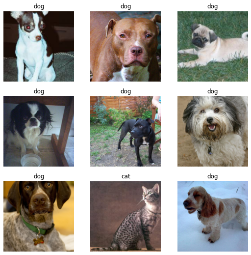

```python
dls = dblock.dataloaders(path/"images")
dls.show_batch()
```

{% endraw %}

The way we usually build the data block in one go is by answering a list of questions:

- what is the types of your inputs/targets? Here images and categories
- where is your data? Here in filenames in subfolders
- does something need to be applied to inputs? Here no
- does something need to be applied to the target? Here the `label_func` function
- how to split the data? Here randomly
- do we need to apply something on formed items? Here a resize
- do we need to apply something on formed batches? Here no

This gives us this design:

{% raw %}

```python
dblock = DataBlock(blocks    = (ImageBlock, CategoryBlock),
                   get_items = get_image_files,
                   get_y     = label_func,
                   splitter  = RandomSplitter(),
                   item_tfms = Resize(224))
```

{% endraw %}

For two questions that got a no, the corresponding arguments we would pass if the anwser was different would be `get_x` and `batch_tfms`.

## Image classification

Let's begin with examples of image classification problems. There are two kinds of image classification problems: problems with single-label (each image has one given label) or multi-label (each image can have multiple or no labels at all). We will cover those two kinds here.

{% raw %}

```python
from fastai.vision.all import *
```

{% endraw %}

### MNIST (single label)

[MNIST](http://yann.lecun.com/exdb/mnist/) is a dataset of hand-written digits from 0 to 9. We can very easily load it in the data block API by answering the following questions:

- what are the types of our inputs and targets? Black and white images and labels.
- where is the data? In subfolders.
- how do we know if a sample is in the training or the validation set? By looking at the grandparent folder.
- how do we know the label of an image? By looking at the parent folder.

In terms of the API, those answers translate like this:

{% raw %}

```python
mnist = DataBlock(blocks=(ImageBlock(cls=PILImageBW), CategoryBlock),
                  get_items=get_image_files,
                  splitter=GrandparentSplitter(),
                  get_y=parent_label)
```

{% endraw %}

Our types become blocks: one for images (using the black and white `PILImageBW` class) and one for categories. Searching subfolder for all image filenames is done by the `get_image_files` function. The split training/validation is done by using a `GrandparentSplitter`. And the function to get our targets (often called `y`) is `parent_label`.

To get an idea of the objects the fastai library provides for reading, labelling or splitting, check the `data.transforms` module.

In itself, a data block is just a blueprint. It does not do anything and does not check for errors. You have to feed it the source of the data to actually gather something. This is done with the `.dataloaders` method:

{% raw %}

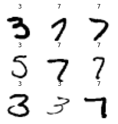

```python
dls = mnist.dataloaders(untar_data(URLs.MNIST_TINY))
dls.show_batch(max_n=9, figsize=(4,4))
```

{% endraw %}

If something went wrong in the previous step, or if you're just curious about what happened under the hood, use the `summary` method. It will go verbosely step by step, and you will see at which point the process failed.

{% raw %}

```python
mnist.summary(untar_data(URLs.MNIST_TINY))
```

```
Setting-up type transforms pipelines
Found 1428 items
2 datasets of sizes 709,699
Setting up Pipeline: PILBase.create
Setting up Pipeline: parent_label -> Categorize -- {'vocab': None, 'sort': True, 'add_na': False}

Building one sample
  Pipeline: PILBase.create
    starting from
      /home/jhoward/.fastai/data/mnist_tiny/train/7/723.png
    applying PILBase.create gives
      PILImageBW mode=L size=28x28
  Pipeline: parent_label -> Categorize -- {'vocab': None, 'sort': True, 'add_na': False}
    starting from
      /home/jhoward/.fastai/data/mnist_tiny/train/7/723.png
    applying parent_label gives
      7
    applying Categorize -- {'vocab': None, 'sort': True, 'add_na': False} gives
      TensorCategory(1)

Final sample: (PILImageBW mode=L size=28x28, TensorCategory(1))


Found 1428 items
2 datasets of sizes 709,699
Setting up Pipeline: PILBase.create
Setting up Pipeline: parent_label -> Categorize -- {'vocab': None, 'sort': True, 'add_na': False}
Setting up after_item: Pipeline: ToTensor
Setting up before_batch: Pipeline:
Setting up after_batch: Pipeline: IntToFloatTensor -- {'div': 255.0, 'div_mask': 1}

Building one batch
Applying item_tfms to the first sample:
  Pipeline: ToTensor
    starting from
      (PILImageBW mode=L size=28x28, TensorCategory(1))
    applying ToTensor gives
      (TensorImageBW of size 1x28x28, TensorCategory(1))

Adding the next 3 samples

No before_batch transform to apply

Collating items in a batch

Applying batch_tfms to the batch built
  Pipeline: IntToFloatTensor -- {'div': 255.0, 'div_mask': 1}
    starting from
      (TensorImageBW of size 4x1x28x28, TensorCategory([1, 1, 1, 1], device='cuda:6'))
    applying IntToFloatTensor -- {'div': 255.0, 'div_mask': 1} gives
      (TensorImageBW of size 4x1x28x28, TensorCategory([1, 1, 1, 1], device='cuda:6'))
```

{% endraw %}

Let's go over another example!

### Pets (single label)

The [Oxford IIIT Pets dataset](https://www.robots.ox.ac.uk/~vgg/data/pets/) is a dataset of pictures of dogs and cats, with 37 different breeds. A slight (but very) important difference with MNIST is that images are now not all of the same size. In MNIST they were all 28 by 28 pixels, but here they have different aspect ratios or dimensions. Therefore, we will need to add something to make them all the same size to be able to assemble them together in a batch. We will also see how to add data augmentation.

So let's go over the same questions as before and add two more:

- what are the types of our inputs and targets? Images and labels.
- where is the data? In subfolders.
- how do we know if a sample is in the training or the validation set? We'll take a random split.
- how do we know the label of an image? By looking at the parent folder.
- do we want to apply a function to a given sample? Yes, we need to resize everything to a given size.
- do we want to apply a function to a batch after it's created? Yes, we want data augmentation.

{% raw %}

```python
pets = DataBlock(blocks=(ImageBlock, CategoryBlock),
                 get_items=get_image_files,
                 splitter=RandomSplitter(),
                 get_y=Pipeline([attrgetter("name"), RegexLabeller(pat = r'^(.*)_\d+.jpg$')]),
                 item_tfms=Resize(128),
                 batch_tfms=aug_transforms())
```

{% endraw %}

And like for MNIST, we can see how the answers to those questions directly translate in the API. Our types become blocks: one for images and one for categories. Searching subfolder for all image filenames is done by the `get_image_files` function. The split training/validation is done by using a `RandomSplitter`. The function to get our targets (often called `y`) is a composition of two transforms: we get the name attribute of our `Path` filenames, then apply a regular expression to get the class. To compose those two transforms into one, we use a [`Pipeline`](https://fastcore.fast.ai/transform#Pipeline).

Finally, We apply a resize at the item level and `aug_transforms()` at the batch level.

{% raw %}

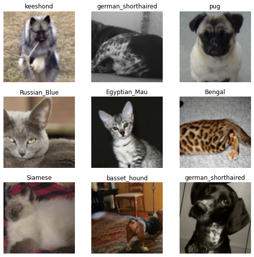

```python
dls = pets.dataloaders(untar_data(URLs.PETS)/"images")
dls.show_batch(max_n=9)
```

{% endraw %}

Now let's see how we can use the same API for a multi-label problem.

### Pascal (multi-label)

The [Pascal dataset](http://host.robots.ox.ac.uk/pascal/VOC/) is originally an object detection dataset (we have to predict where some objects are in pictures). But it contains lots of pictures with various objects in them, so it gives a great example for a multi-label problem. Let's download it and have a look at the data:

{% raw %}

```python
pascal_source = untar_data(URLs.PASCAL_2007)
df = pd.read_csv(pascal_source/"train.csv")
```

{% endraw %} {% raw %}

```python
df.head()
```

|  | fname | labels | is_valid |
| --- | --- | --- | --- |
| 0 | 000005.jpg | chair | True |
| 1 | 000007.jpg | car | True |
| 2 | 000009.jpg | horse person | True |
| 3 | 000012.jpg | car | False |
| 4 | 000016.jpg | bicycle | True |

{% endraw %}

So it looks like we have one column with filenames, one column with the labels (separated by space) and one column that tells us if the filename should go in the validation set or not.

There are multiple ways to put this in a `DataBlock`, let's go over them, but first, let's answer our usual questionnaire:

- what are the types of our inputs and targets? Images and multiple labels.
- where is the data? In a dataframe.
- how do we know if a sample is in the training or the validation set? A column of our dataframe.
- how do we get an image? By looking at the column fname.
- how do we know the label of an image? By looking at the column labels.
- do we want to apply a function to a given sample? Yes, we need to resize everything to a given size.
- do we want to apply a function to a batch after it's created? Yes, we want data augmentation.

Notice how there is one more question compared to before: we wont have to use a `get_items` function here because we already have all our data in one place. But we will need to do something to the raw dataframe to get our inputs, read the first column and add the proper folder before the filename. This is what we pass as `get_x`.

{% raw %}

```python
pascal = DataBlock(blocks=(ImageBlock, MultiCategoryBlock),
                   splitter=ColSplitter(),
                   get_x=ColReader(0, pref=pascal_source/"train"),
                   get_y=ColReader(1, label_delim=' '),
                   item_tfms=Resize(224),
                   batch_tfms=aug_transforms())
```

{% endraw %}

Again, we can see how the answers to the questions directly translate in the API. Our types become blocks: one for images and one for multi-categories. The split is done by a `ColSplitter` (it defaults to the column named `is_valid`). The function to get our inputs (often called `x`) is a `ColReader` on the first column with a prefix, the function to get our targets (often called `y`) is `ColReader` on the second column, with a space delimiter. We apply a resize at the item level and `aug_transforms()` at the batch level.

{% raw %}

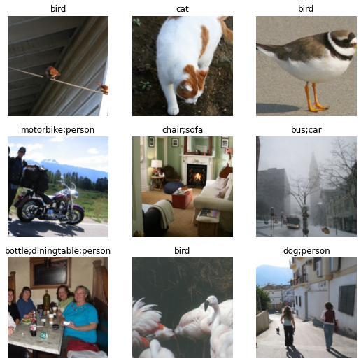

```python
dls = pascal.dataloaders(df)
dls.show_batch()
```

{% endraw %}

Another way to do this is by directly using functions for `get_x` and `get_y`:

{% raw %}

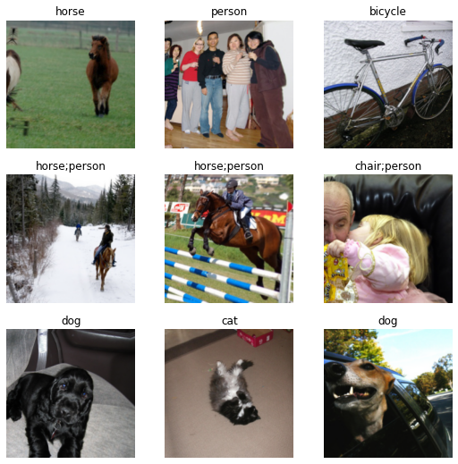

```python
pascal = DataBlock(blocks=(ImageBlock, MultiCategoryBlock),
                   splitter=ColSplitter(),
                   get_x=lambda x:pascal_source/"train"/f'{x[0]}',
                   get_y=lambda x:x[1].split(' '),
                   item_tfms=Resize(224),
                   batch_tfms=aug_transforms())

dls = pascal.dataloaders(df)
dls.show_batch()
```

{% endraw %}

Alternatively, we can use the names of the columns as attributes (since rows of a dataframe are pandas series).

{% raw %}

[figure not shown]

```python
pascal = DataBlock(blocks=(ImageBlock, MultiCategoryBlock),
                   splitter=ColSplitter(),
                   get_x=lambda o:f'{pascal_source}/train/'+o.fname,
                   get_y=lambda o:o.labels.split(),
                   item_tfms=Resize(224),
                   batch_tfms=aug_transforms())

dls = pascal.dataloaders(df)
dls.show_batch()
```

{% endraw %}

The most efficient way (to avoid iterating over the rows of the dataframe, which can take a long time) is to use the `from_columns` method. It will use `get_items` to convert the columns into numpy arrays. The drawback is that since we lose the dataframe after extracting the relevant columns, we can't use a `ColSplitter` anymore. Here we used an `IndexSplitter` after manually extracting the index of the validation set from the dataframe:

{% raw %}

```python
def _pascal_items(x): return (
    f'{pascal_source}/train/'+x.fname, x.labels.str.split())
valid_idx = df[df['is_valid']].index.values

pascal = DataBlock.from_columns(blocks=(ImageBlock, MultiCategoryBlock),
                   get_items=_pascal_items,
                   splitter=IndexSplitter(valid_idx),
                   item_tfms=Resize(224),
                   batch_tfms=aug_transforms())
```

{% endraw %} {% raw %}

[figure not shown]

```python
dls = pascal.dataloaders(df)
dls.show_batch()
```

{% endraw %}

## Image localization

There are various problems that fall in the image localization category: image segmentation (which is a task where you have to predict the class of each pixel of an image), coordinate predictions (predict one or several key points on an image) and object detection (draw a box around objects to detect).

Let's see an example of each of those and how to use the data block API in each case.

### Segmentation

We will use a small subset of the [CamVid dataset](http://mi.eng.cam.ac.uk/research/projects/VideoRec/CamVid/) for our example.

{% raw %}

```python
path = untar_data(URLs.CAMVID_TINY)
```

{% endraw %}

Let's go over our usual questionnaire:

- what are the types of our inputs and targets? Images and segmentation masks.
- where is the data? In subfolders.
- how do we know if a sample is in the training or the validation set? We'll take a random split.
- how do we know the label of an image? By looking at a corresponding file in the "labels" folder.
- do we want to apply a function to a batch after it's created? Yes, we want data augmentation.

{% raw %}

```python
camvid = DataBlock(blocks=(ImageBlock, MaskBlock(codes = np.loadtxt(path/'codes.txt', dtype=str))),
    get_items=get_image_files,
    splitter=RandomSplitter(),
    get_y=lambda o: path/'labels'/f'{o.stem}_P{o.suffix}',
    batch_tfms=aug_transforms())
```

{% endraw %}

The `MaskBlock` is generated with the `codes` that give the correpondence between pixel value of the masks and the object they correspond to (like car, road, pedestrian...). The rest should look pretty familiar by now.

{% raw %}

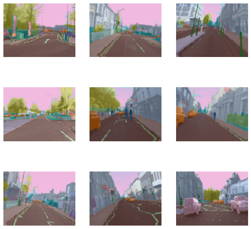

```python
dls = camvid.dataloaders(path/"images")
dls.show_batch()
```

{% endraw %}

### Points

For this example we will use a small sample of the [BiWi kinect head pose dataset](https://www.kaggle.com/kmader/biwi-kinect-head-pose-database). It contains pictures of people and the task is to predict where the center of their head is. We have saved this small dataet with a dictionary filename to center:

{% raw %}

```python
biwi_source = untar_data(URLs.BIWI_SAMPLE)
fn2ctr = load_pickle(biwi_source/'centers.pkl')
```

{% endraw %}

Then we can go over our usual questions:

- what are the types of our inputs and targets? Images and points.
- where is the data? In subfolders.
- how do we know if a sample is in the training or the validation set? We'll take a random split.
- how do we know the label of an image? By using the `fn2ctr` dictionary.
- do we want to apply a function to a batch after it's created? Yes, we want data augmentation.

{% raw %}

```python
biwi = DataBlock(blocks=(ImageBlock, PointBlock),
                 get_items=get_image_files,
                 splitter=RandomSplitter(),
                 get_y=lambda o:fn2ctr[o.name].flip(0),
                 batch_tfms=aug_transforms())
```

{% endraw %}

And we can use it to create a `DataLoaders`:

{% raw %}

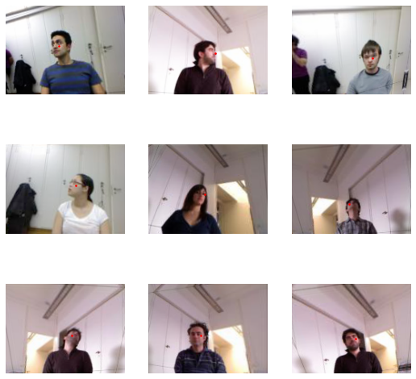

```python
dls = biwi.dataloaders(biwi_source)
dls.show_batch(max_n=9)
```

{% endraw %}

### Bounding boxes

For this task, we will use a small subset of the [COCO dataset](http://cocodataset.org/#home). It contains pictures with day-to-day objects and the goal is to predict where the objects are by drawing a rectangle around them.

The fastai library comes with a function called `get_annotations` that will interpret the content of `train.json` and give us a dictionary filename to (bounding boxes, labels).

{% raw %}

```python
coco_source = untar_data(URLs.COCO_TINY)
images, lbl_bbox = get_annotations(coco_source/'train.json')
img2bbox = dict(zip(images, lbl_bbox))
```

{% endraw %}

Then we can go over our usual questions:

- what are the types of our inputs and targets? Images and bounding boxes.
- where is the data? In subfolders.
- how do we know if a sample is in the training or the validation set? We'll take a random split.
- how do we know the label of an image? By using the `img2bbox` dictionary.
- do we want to apply a function to a given sample? Yes, we need to resize everything to a given size.
- do we want to apply a function to a batch after it's created? Yes, we want data augmentation.

{% raw %}

```python
coco = DataBlock(blocks=(ImageBlock, BBoxBlock, BBoxLblBlock),
                 get_items=get_image_files,
                 splitter=RandomSplitter(),
                 get_y=[lambda o: img2bbox[o.name][0], lambda o: img2bbox[o.name][1]],
                 item_tfms=Resize(128),
                 batch_tfms=aug_transforms(),
                 n_inp=1)
```

{% endraw %}

Note that we provide three types, because we have two targets: the bounding boxes and the labels. That's why we pass `n_inp=1` at the end, to tell the library where the inputs stop and the targets begin.

This is also why we pass a list to `get_y`: since we have two targets, we must tell the library how to label for each of them (you can use `noop` if you don't want to do anything for one).

{% raw %}

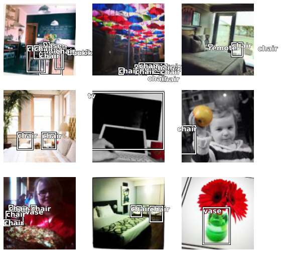

```python
dls = coco.dataloaders(coco_source)
dls.show_batch(max_n=9)
```

{% endraw %}

## Text

We will show two examples: language modeling and text classification. Note that with the data block API, you can adapt the example before for multi-label to a problem where the inputs are texts.

{% raw %}

```python
from fastai.text.all import *
```

{% endraw %}

### Language model

We will use a dataset compose of movie reviews from IMDb. As usual, we can download it in one line of code with `untar_data`.

{% raw %}

```python
path = untar_data(URLs.IMDB_SAMPLE)
df = pd.read_csv(path/'texts.csv')
df.head()
```

|  | label | text | is_valid |
| --- | --- | --- | --- |
| 0 | negative | Un-bleeping-believable! Meg Ryan doesn't even look her usual pert lovable self in this, which normally makes me forgive her shallow ticky acting schtick. Hard to believe she was the producer on this d… | False |
| 1 | positive | This is a extremely well-made film. The acting, script and camera-work are all first-rate. The music is good, too, though it is mostly early in the film, when things are still relatively cheery. There… | False |
| 2 | negative | Every once in a long while a movie will come along that will be so awful that I feel compelled to warn people. If I labor all my days and I can save but one soul from watching this movie, how great wi… | False |
| 3 | positive | Name just says it all. I watched this movie with my dad when it came out and having served in Korea he had great admiration for the man. The disappointing thing about this film is that it only concent… | False |
| 4 | negative | This movie succeeds at being one of the most unique movies you've seen. However this comes from the fact that you can't make heads or tails of this mess. It almost seems as a series of challenges set … | False |

{% endraw %}

We can see it's composed of (pretty long!) reviews labeled positive or negative. Let's go over our usual questions:

- what are the types of our inputs and targets? Texts and we don't really have targets, since the targets is derived from the inputs.
- where is the data? In a dataframe.
- how do we know if a sample is in the training or the validation set? We have an `is_valid` column.
- how do we get our inputs? In the `text` column.

{% raw %}

```python
imdb_lm = DataBlock(blocks=TextBlock.from_df('text', is_lm=True),
                    get_x=ColReader('text'),
                    splitter=ColSplitter())
```

{% endraw %}

Since there are no targets here, we only have one block to specify. `TextBlock`s are a bit special compared to other `TransformBlock`s: to be able to efficiently tokenize all texts during setup, you need to use the class methods `from_folder` or `from_df`.

Note: the `TestBlock` tokenization process puts tokenized inputs into a column called `text`. The `ColReader` for `get_x` will always reference `text`, even if the original text inputs were in a column with another name in the dataframe.

We can then get our data into `DataLoaders` by passing the dataframe to the `dataloaders` method:

{% raw %}

```python
dls = imdb_lm.dataloaders(df, bs=64, seq_len=72)
dls.show_batch(max_n=6)
```

|  | text | text_ |
| --- | --- | --- |
| 0 | xxbos xxmaj this movie is just so awful . xxmaj so bad that i ca n't bear to xxunk anything other than just a few words . xxmaj avoid this movie at all costs , it is terrible . \n\n xxmaj none of the … | xxmaj this movie is just so awful . xxmaj so bad that i ca n't bear to xxunk anything other than just a few words . xxmaj avoid this movie at all costs , it is terrible . \n\n xxmaj none of the detail… |
| 1 | xxmaj there is some gore , but it mostly looks clumsy and is n't as fun too look at as it is the case with most other xxmaj naschy films . xxmaj overall , " el xxmaj mariscal xxmaj del xxmaj infierno … | there is some gore , but it mostly looks clumsy and is n't as fun too look at as it is the case with most other xxmaj naschy films . xxmaj overall , " el xxmaj mariscal xxmaj del xxmaj infierno " is o… |
| 2 | xxunk can be good . xxmaj maybe the producer and maybe the director but hopefully they were not serious when they made this xxup thing . xxmaj this whole movie is like making a greatest hits xxup dvd … | can be good . xxmaj maybe the producer and maybe the director but hopefully they were not serious when they made this xxup thing . xxmaj this whole movie is like making a greatest hits xxup dvd of the… |
| 3 | do anything . i am not sure how much xxmaj john xxunk - xxunk got , but most of the money he made should go to his fans as an apology for even being associated with such a xxup rotten movie . xxmaj th… | anything . i am not sure how much xxmaj john xxunk - xxunk got , but most of the money he made should go to his fans as an apology for even being associated with such a xxup rotten movie . xxmaj the s… |
| 4 | . xxbos xxmaj this film stars , among others , " xxunk " xxmaj xxunk xxmaj offer ( who also wrote , edited and directed ) and xxmaj joey xxmaj xxunk -- not exactly names that scream out " quality " . … | xxbos xxmaj this film stars , among others , " xxunk " xxmaj xxunk xxmaj offer ( who also wrote , edited and directed ) and xxmaj joey xxmaj xxunk -- not exactly names that scream out " quality " . xx… |
| 5 | to rub my eyes when i realised it was made in 2001 , and not 1971 . xxmaj even the clothes and fashioned look about three decades out of date ! \n\n xxmaj if you think xxmaj i 'm not qualified to do a… | rub my eyes when i realised it was made in 2001 , and not 1971 . xxmaj even the clothes and fashioned look about three decades out of date ! \n\n xxmaj if you think xxmaj i 'm not qualified to do a re… |

{% endraw %}

### Text classification

For the text classification, let's go over our usual questions:

- what are the types of our inputs and targets? Texts and categories.
- where is the data? In a dataframe.
- how do we know if a sample is in the training or the validation set? We have an `is_valid` column.
- how do we get our inputs? In the `text` column.
- how do we get our targets? In the `label` column.

{% raw %}

```python
imdb_clas = DataBlock(blocks=(TextBlock.from_df('text', seq_len=72, vocab=dls.vocab), CategoryBlock),
                      get_x=ColReader('text'),
                      get_y=ColReader('label'),
                      splitter=ColSplitter())
```

{% endraw %}

Like in the previous example, we use a class method to build a `TextBlock`. We can pass it the vocabulary of our language model (very useful for the ULMFit approach). We also show the `seq_len` argument (which defaults to 72) just because you need to make sure to use the same here and also in your `text_classifier_learner`.

{% include warning.html content='You need to make sure to use the same `seq_len` in `TextBlock` and the `Learner` you will define later on.' %}

{% raw %}

```python
dls = imdb_clas.dataloaders(df, bs=64)
dls.show_batch()
```

[output not shown]

|  | text | category |
| --- | --- | --- |
| 0 | xxbos xxmaj raising xxmaj victor xxmaj vargas : a xxmaj review \n\n xxmaj you know , xxmaj raising xxmaj victor xxmaj vargas is like sticking your hands into a big , xxunk bowl of xxunk . xxmaj it 's … | negative |
| 1 | xxbos xxup the xxup shop xxup around xxup the xxup corner is one of the xxunk and most feel - good romantic comedies ever made . xxmaj there 's just no getting around that , and it 's hard to actually… | positive |
| 2 | xxbos xxmaj now that xxmaj che(2008 ) has finished its relatively short xxmaj australian cinema run ( extremely limited xxunk screen in xxmaj xxunk , after xxunk ) , i can xxunk join both xxunk of " a… | negative |
| 3 | xxbos xxmaj this film sat on my xxmaj xxunk for weeks before i watched it . i xxunk a self - indulgent xxunk flick about relationships gone bad . i was wrong ; this was an xxunk xxunk into the screwed… | positive |
| 4 | xxbos i really wanted to love this show . i truly , honestly did . \n\n xxmaj for the first time , gay viewers get their own version of the " the xxmaj bachelor " . xxmaj with the help of his obligato… | negative |
| 5 | xxbos xxmaj many neglect that this is n't just a classic due to the fact that it 's the first 3d game , or even the first xxunk - up . xxmaj it 's also one of the first xxunk games , one of the xxunk … | positive |
| 6 | xxbos xxmaj the xxmaj blob starts with one of the most bizarre theme songs ever , xxunk by an uncredited xxmaj burt xxmaj xxunk of all people ! xxmaj you really have to hear it to believe it , xxmaj t… | negative |
| 7 | xxbos xxmaj the year 2005 saw no xxunk than 3 filmed productions of xxup h. xxup g. xxmaj wells ' great novel , " war of the xxmaj worlds " . xxmaj this is perhaps the least well - known and very prob… | positive |
| 8 | xxbos xxmaj well , what can i say . \n\n " what the xxmaj xxunk do we xxmaj know " has achieved the nearly impossible - leaving behind such masterpieces of the genre as " the xxmaj xxunk " , " the xxm… | negative |

{% endraw %}

## Tabular data

Tabular data doesn't really use the data block API as it's relying on another API with `TabularPandas` for efficient preprocessing and batching (there will be some less efficient API that plays nicely with the data block API added in the near future). You can still use different blocks for the targets.

{% raw %}

```python
from fastai.tabular.core import *
```

{% endraw %}

For our example, we will look at a subset of the [adult dataset](https://archive.ics.uci.edu/ml/datasets/adult) which contains some census data and where the task is to predict if someone makes more than 50k or not.

{% raw %}

```python
adult_source = untar_data(URLs.ADULT_SAMPLE)
df = pd.read_csv(adult_source/'adult.csv')
df.head()
```

|  | age | workclass | fnlwgt | education | education-num | marital-status | occupation | relationship | race | sex | capital-gain | capital-loss | hours-per-week | native-country | salary |
| --- | --- | --- | --- | --- | --- | --- | --- | --- | --- | --- | --- | --- | --- | --- | --- |
| 0 | 49 | Private | 101320 | Assoc-acdm | 12.0 | Married-civ-spouse | NaN | Wife | White | Female | 0 | 1902 | 40 | United-States | >=50k |
| 1 | 44 | Private | 236746 | Masters | 14.0 | Divorced | Exec-managerial | Not-in-family | White | Male | 10520 | 0 | 45 | United-States | >=50k |
| 2 | 38 | Private | 96185 | HS-grad | NaN | Divorced | NaN | Unmarried | Black | Female | 0 | 0 | 32 | United-States | <50k |
| 3 | 38 | Self-emp-inc | 112847 | Prof-school | 15.0 | Married-civ-spouse | Prof-specialty | Husband | Asian-Pac-Islander | Male | 0 | 0 | 40 | United-States | >=50k |
| 4 | 42 | Self-emp-not-inc | 82297 | 7th-8th | NaN | Married-civ-spouse | Other-service | Wife | Black | Female | 0 | 0 | 50 | United-States | <50k |

{% endraw %}

In a tabular problem, we need to split the columns between the ones that represent continuous variables (like the age) and the ones that represent categorical variables (like the education):

{% raw %}

```python
cat_names = ['workclass', 'education', 'marital-status', 'occupation', 'relationship', 'race']
cont_names = ['age', 'fnlwgt', 'education-num']
```

{% endraw %}

Standard preprocessing in fastai, use those pre-processors:

{% raw %}

```python
procs = [Categorify, FillMissing, Normalize]
```

{% endraw %}

`Categorify` will change the categorical columns into indices, `FillMissing` will fill the missing values in the continuous columns (if any) and add an na categorical column (if necessary). `Normalize` will normalize the continuous columns (subtract the mean and divide by the standard deviation).

We can still use any splitter to create the splits as we'd like them:

{% raw %}

```python
splits = RandomSplitter()(range_of(df))
```

{% endraw %}

And then everything goes in a `TabularPandas` object:

{% raw %}

```python
to = TabularPandas(df, procs, cat_names, cont_names, y_names="salary", splits=splits, y_block=CategoryBlock)
```

{% endraw %}

We put `y_block=CategoryBlock` just to show you how to customize the block for the targets, but it's usually inferred from the data, so you don't need to pass it, normally.

{% raw %}

```python
dls = to.dataloaders()
dls.show_batch()
```

|  | workclass | education | marital-status | occupation | relationship | race | education-num_na | age | fnlwgt | education-num | salary |
| --- | --- | --- | --- | --- | --- | --- | --- | --- | --- | --- | --- |
| 0 | Local-gov | Some-college | Divorced | Other-service | Unmarried | White | False | 41.000000 | 173050.999321 | 10.0 | <50k |
| 1 | Federal-gov | Assoc-acdm | Divorced | Other-service | Unmarried | White | False | 33.000000 | 339388.005812 | 12.0 | <50k |
| 2 | Private | HS-grad | Never-married | #na# | Own-child | White | True | 29.000000 | 84560.004846 | 10.0 | <50k |
| 3 | Private | Bachelors | Married-civ-spouse | Adm-clerical | Wife | Black | False | 33.000000 | 376482.998606 | 13.0 | <50k |
| 4 | Private | Assoc-acdm | Separated | Tech-support | Unmarried | White | False | 40.000000 | 260424.999250 | 12.0 | <50k |
| 5 | Private | Some-college | Never-married | Exec-managerial | Own-child | White | False | 24.000001 | 314165.003107 | 10.0 | <50k |
| 6 | Private | HS-grad | Never-married | #na# | Unmarried | White | False | 20.000000 | 323009.000435 | 9.0 | <50k |
| 7 | Private | HS-grad | Divorced | Adm-clerical | Unmarried | White | False | 38.000000 | 278253.001491 | 9.0 | <50k |
| 8 | Local-gov | HS-grad | Married-civ-spouse | Craft-repair | Husband | White | False | 64.000001 | 142165.999769 | 9.0 | <50k |
| 9 | Private | HS-grad | Married-civ-spouse | Craft-repair | Husband | White | False | 35.000000 | 180686.000212 | 9.0 | <50k |

{% endraw %}